# C04 — Od pozycji do konstruktu: samoocena i wykonanie zadania

Zarządzanie informacją — ćwiczenie i zadanie Z04 — 2026/27

2026/27

# Początek pracy na ćwiczeniu C04

Otwórz swój projekt kursu w Posit Cloud albo RStudio na własnym komputerze; pakiet kursu `badaniaZI` jest w nim zainstalowany. Dwa polecenia z następnego bloku wpisujesz w konsoli RStudio, czyli w dolnym panelu ze znakiem `>`; w miejsce `TWOJE_ID` wpisz swoje ID, a w miejsce `Imię Nazwisko` — swoje imię i nazwisko. Dokument PDF zawiera dwa polecenia jako tekst instrukcji.

```r
library(badaniaZI)
rozpocznij_zajecia("C04", id_studenta = "TWOJE_ID", student = "Imię Nazwisko")
```

Sprawdź w komunikacie ID oraz imię i nazwisko. Przy pierwszym starcie funkcja tworzy folder `moje-badania` i zapisuje w nim oba dane; pliki pracy zachowują je także po zamknięciu projektu, a imię i nazwisko trafiają do nazwy oddawanego pliku.

Funkcja `rozpocznij_zajecia()` otwiera własny plik `zadanie.Rmd`, zapamiętuje katalog pracy i kopiuje do folderu `moje-badania/materialy` wersję HTML i PDF ćwiczenia oraz rubrykę zadania. Pracuj w otwartym pliku `zadanie.Rmd` do końca zajęć. Najpierw uruchom blok `przygotowanie`, a potem kolejne części LEARN i CHALLENGE. Przy problemie poproś prowadzącego o pomoc; plik pracy i własne ID pozostają bez zmian.

Pierwszy chunk, `przygotowanie`, wczytuje gotowy skrypt `analiza.R`. Skrypt tworzy zbiór S02 po trzech regułach ćwiczenia C02 (usunięcie identycznych duplikatów, kod 99 w pozycjach ankiety jako brak, czas spoza 0–120 minut jako brak), odwraca kierunek pozycji 3, liczy indeks sześciu pozycji i odsetki kanałów informacji. Zawiera też małą demonstrację sześciu osób a–f, dane cyfrowego archiwum a1–a8 do części CHALLENGE oraz funkcje wyświetlające tabele i wykresy. Skrypt działa bez zmian.

# Biblioteka pyta o kompetencje, ankieta pyta o katalog

Ćwiczenie C03 (Portret próby) opisało czas wyszukiwania (142 ważne pomiary, mediana 8,25 minuty) i powodzenie (97 ze 148 osób, 65,5%). Zespół biblioteki pyta, czy trudności wiążą się z kompetencjami użytkowników, i proponuje: „Policzmy średnią z sześciu odpowiedzi; wysoki wynik oznacza wysokie kompetencje cyfrowe”. Obliczenie zaczyna się od przeczytania pytań.

Sześć pozycji S02 dotyczy znajdowania pola wyszukiwania, zrozumiałości filtrów, odczytywania rekordu, lokalizacji dokumentu, komunikatów i wsparcia zadania. Część pozycji opisuje deklarowane działanie osoby, część — ocenę interfejsu. Sześć pozycji obejmuje wąski fragment kompetencji: obsługę katalogu i ocenę jego elementów. Nazwa **indeks deklarowanej użyteczności katalogu** opisuje treść pozycji i jest nazwą roboczą podsumowania dydaktycznego.

Nazwa konstruktu wyznacza decyzję instytucji. Niski wynik przypisany brakowi kompetencji prowadzi do szkolenia użytkowników, a ten sam wynik przypisany katalogowi — do poprawy etykiet i komunikatów. Wysoki wynik uznany za dowód sprawności wyszukiwania ukrywa niepoprawne wykonanie zadania. Pomiar określa zakres dopuszczalnej decyzji.

Dane kursu są syntetyczne. Publikacje o zachowaniach informacyjnych i pomiarze umiejętności dostarczają kontekstu, a rekordy S02 pochodzą z generatora pakietu. Małe przykłady oznaczone jako demonstracje przedstawiają osoby wymyślone do ćwiczenia.

## Przebieg spotkania

Przeznacz około 5 minut na odtworzenie pracy, 30 minut na pięć bloków LEARN, 50 minut na pięć zadań CHALLENGE i 5 minut na zapis oraz oddanie. W LEARN uruchamiasz gotowy kod i porównujesz wynik z podaną interpretacją. W CHALLENGE piszesz własne krótkie akapity pod wynikami, poza blokiem R. Gdy odczyt wyniku sprawia trudność, pytasz prowadzącego. Rozwinięcia po części obowiązkowej służą powtórce i pozostają poza oceną. Projekt indywidualny rozpoczyna się na ćwiczeniu C09 (Warsztat projektu).

Po spotkaniu umiesz przeczytać wzór indeksu, prześledzić jeden rekord, uzasadnić mianownik i nazwać zakres pomiaru. Najważniejsza umiejętność: wyjaśnić, jaka informacja zostaje w indeksie, a jaka pozostaje w pojedynczych pozycjach.

Bloki LEARN kończą się **wzorcem zapisu** — przykładowym zdaniem według standardu APA (*Publication Manual of the American Psychological Association*, 7. wydanie, 2020): symbol statystyczny kursywą, skala odpowiedzi przy wyniku, przecinek jako separator dziesiętny. Na ćwiczeniu C04 wzorce dotyczą opisu pomiaru: rozkładu pozycji, rekodacji, indeksu, odpowiedzi wielokrotnych oraz deklaracji i wykonania. Zadania CHALLENGE stosują wzorce do ankiety cyfrowego archiwum.

# LEARN 1: od konstruktu do konkretnego zdania

Konstrukt jest pojęciem teoretycznym, np. kompetencja informacyjna, poczucie skuteczności albo postrzegana użyteczność usługi. Wskaźnik jest obserwowalną odpowiedzią lub zachowaniem, które dostarcza informacji o konstrukcie. Operacjonalizacja opisuje procedurę uzyskania i interpretacji wskaźnika.

Wypowiedź „umiem znaleźć wiarygodne źródło” jest deklaracją. Prawidłowe wskazanie autora, daty i podstawy twierdzenia w konkretnym zadaniu jest obserwacją wykonania. Liczba kliknięć jest śladem interakcji. Każdy z trzech pomiarów obejmuje wycinek szerokiego konstruktu.

[Hargittai (2002)](https://webuse.org/p/a09/) łączy informacje o użytkowniku z obserwacją wykonywania zadań. [Internet Skills Scale](https://eprints.lse.ac.uk/64485/) (ISS) jest przykładem skali z własnym procesem opracowania i walidacji. Dowody jakości ISS dotyczą pozycji ISS; sześć pozycji S02 wymaga własnych dowodów.

## Audyt pozycji S02

Sześć pozycji S02 i ich treść

| Pozycja | Treść w słowniku | Co deklaruje osoba? |
| --- | --- | --- |
| 1 | Szybko znajduję pole wyszukiwania w katalogu. | Własną łatwość odnalezienia elementu |
| 2 | Nazwy filtrów są dla mnie zrozumiałe. | Zrozumiałość etykiet |
| 3 | Odczytanie rekordu wymaga ode mnie zgadywania. | Trudność interpretacji rekordu |
| 4 | Potrafię znaleźć lokalizację dokumentu. | Własną możliwość wykonania czynności |
| 5 | Komunikaty katalogu pomagają mi poprawić zapytanie. | Przydatność pomocy systemu |
| 6 | Katalog wspiera wykonanie mojego zadania. | Ogólną ocenę wsparcia |

Pozycja 3 ma przeciwny kierunek: wysoka odpowiedź oznacza większą trudność, a w pozostałych pozycjach — korzystną ocenę. Rekodacja rozwiązuje problem techniczny kierunku liczb. Różnorodność treści pozycji jest problemem interpretacyjnym: odwrócenie ujednolica kierunek, a wspólną cechę pozycji ocenia się na podstawie treści i korelacji pozycji (rozwinięcie „Rzetelność i trafność”).

Zdanie „osoba twierdzi, że potrafi znaleźć lokalizację” jest zgodne z pozycją 4. Zdanie „osoba prawidłowo znalazła lokalizację” wymaga obserwacji działania. Raport używa zdania zgodnego z pomiarem.

Nazwy techniczne pozostają krótkie: `pozycja_1`, `indeks`, `powodzenie`. Pełne znaczenie zapisuje słownik i tekst raportu. Nazwę konstruktu ustala się na podstawie treści pozycji danego badania.

## Jedna odpowiedź i jej rozkład

Pojedyncza pozycja ma pięć uporządkowanych odpowiedzi: od „zdecydowanie nie” (1) do „zdecydowanie tak” (5). Kod 5 oznacza silniejsze potwierdzenie niż 4; odległości między kategoriami pozostają nieznane, więc pozycja ma skalę porządkową. Rozkład pozycji opisują udziały kategorii i udziały skumulowane:

$$f_j=\frac{n_j}{n},\qquad F_j=\sum_{l\le j} f_l ,$$

gdzie $n_j$ to liczba odpowiedzi w kategorii $j$, $n$ — liczba ważnych odpowiedzi na pozycję, a $F_j$ — udział odpowiedzi nie wyższych niż $j$. Dominanta jest kategorią o największym $f_j$.

Tabela „Oryginalna pozycja 3 — stopień zgody” opisuje pozycję 3 przed odwróceniem. Odpowiedzi udzieliły 144 osoby, a 4 osoby mają brak. Liczby w kategoriach 1–5 wynoszą 18, 39, 58, 26 i 3, czyli 12,5%, 27,1%, 40,3%, 18,1% i 2,1%; odsetki skumulowane $F_j$ wynoszą 12,5%, 39,6%, 79,9%, 97,9% i 100%. Dominantą jest kategoria 3.

```r
pozycja <- opis_pozycji(pozycja_3_opis, "Oryginalna pozycja 3 — stopień zgody")
print(pozycja)
```

**Oryginalna pozycja 3 — stopień zgody**

| Odpowiedź | Liczba | Procent [%] | Skumulowany [%] |
| --- | --- | --- | --- |
| 1 | 18 | 12,5 | 12,5 |
| 2 | 39 | 27,1 | 39,6 |
| 3 | 58 | 40,3 | 79,9 |
| 4 | 26 | 18,1 | 97,9 |
| 5 | 3 | 2,1 | 100,0 |

Odpowiedzi 4 i 5 oznaczają deklarowaną potrzebę zgadywania przy odczycie rekordu, więc wysoki udział odpowiedzi 4 i 5 opisuje trudność. Najpierw czyta się brzmienie pozycji, potem numer odpowiedzi.

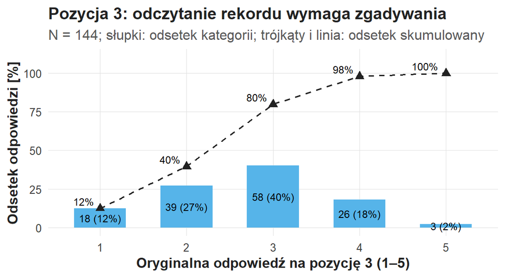

Pozycja 3: odczytanie rekordu wymaga zgadywania (N = 144). Oś pozioma: oryginalna odpowiedź 1–5; oś pionowa: odsetek ważnych odpowiedzi. Słupki: 18 (12%), 39 (27%), 58 (40%), 26 (18%) i 3 (2%) odpowiedzi. Trójkąty połączone linią przerywaną podają odsetek skumulowany: 12%, 40%, 80%, 98% i 100%.

```r
odpowiedzi <- pokaz_wykres(wykres_pozycji)
print(odpowiedzi)
```

Słupki stoją osobno, bo kategorie odpowiedzi są oddzielnymi punktami skali; linia przerywana łączy wyłącznie odsetki skumulowane. W pozycji porządkowej odczytuje się dominantę, odsetki skumulowane i kategorię środkową według uzgodnionej konwencji. Średnia kodów bywa przybliżeniem, którego interpretacja zależy od założenia o odległościach kategorii.

Wykres „Sześć pozycji S02 po ukierunkowaniu” zestawia rozkłady wszystkich pozycji po odwróceniu pozycji 3. Każda pozycja ma 144 ważne odpowiedzi.

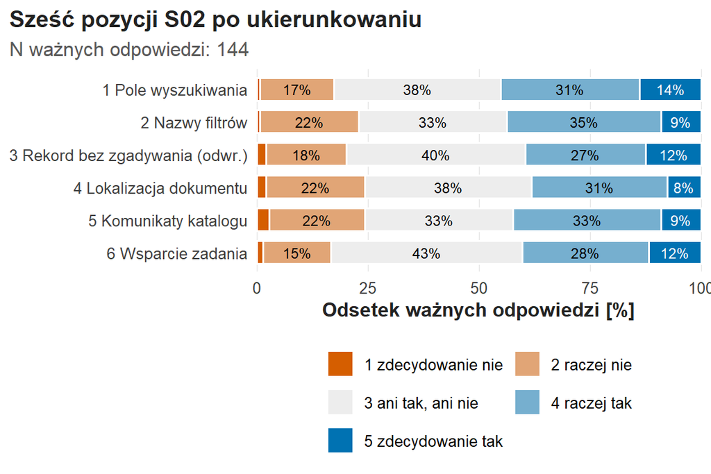

Sześć pozycji S02 po ukierunkowaniu (N = 144 w każdej pozycji). Każda pozioma belka ma długość 100% ważnych odpowiedzi pozycji; odcinki od lewej odpowiadają odpowiedziom od 1 (zdecydowanie nie) do 5 (zdecydowanie tak). Udział odpowiedzi 4 i 5 wynosi od 38,2% (pozycja 4) do 45,1% (pozycja 1), a odpowiedź 3 zajmuje od 33% do 43% każdej belki.

```r
szesc_pozycji <- pokaz_wykres(wykres_szesciu_pozycji)
print(szesc_pozycji)
```

Rozkłady sześciu pozycji są podobne: odpowiedzi 4 i 5 stanowią od 38,2% do 45,1%, a odpowiedzi 1 i 2 — od 16,7% (pozycja 6) do 24,3% (pozycje 4 i 5). Podobieństwo rozkładów jest warunkiem rozsądnego łączenia pozycji w indeks; wspólną treść pozycji ocenia się osobno.

**Wzorzec zapisu rozkładu pozycji (APA).**

> Na pozycję 3 („Odczytanie rekordu wymaga ode mnie zgadywania”) odpowiedziały 144 osoby (4 braki). Najczęściej wybierano odpowiedź 3 (*n* = 58; 40,3%), a odpowiedzi 4 i 5 łącznie wybrało 29 osób (20,1% ważnych odpowiedzi); odsetek opisuje deklarowaną trudność odczytania rekordu, a błędy w zadaniu mierzy obserwacja.

# LEARN 2: odwrócenie kierunku pozycji 3

Dla zakresu od 1 do 5 rekodacja ma postać:

$$x^*_{i3}=1+5-x_{i3}=6-x_{i3}.$$

Wzór brzmi słownie: „ukierunkowana odpowiedź osoby $i$ na pozycję 3 równa się sumie końców skali minus odpowiedź pierwotna”. Pierwotne 5, oznaczające największą trudność, staje się 1 w kierunku korzystnej oceny, a środek 3 pozostaje równy 3.

Tabela „Ta sama odpowiedź w przeciwnym kierunku” podaje wszystkie przejścia: $1\leftrightarrow5$, $2\leftrightarrow4$ i $3\leftrightarrow3$. Ponowne odwrócenie przywraca kod pierwotny, więc dwukrotne wykonanie rekodacji jest błędem.

```r
kierunek <- pokaz_tabele(odwrocenie, "Ta sama odpowiedź w przeciwnym kierunku", 0L)
print(kierunek)
```

**Ta sama odpowiedź w przeciwnym kierunku**

| Odpowiedź x | Po odwróceniu 6 − x |
| --- | --- |
| 1 | 5 |
| 2 | 4 |
| 3 | 3 |
| 4 | 2 |
| 5 | 1 |

Ogólna reguła dla skali od $a$ do $b$ ma postać $a+b-x$; dla zakresu 0–4 reguła brzmi $4-x$. Przepisanie reguły z innego badania wymaga sprawdzenia zakresu skali.

Kod 99 zamienia się na `NA` przed rekodacją, bo $6-99=-93$ leży poza skalą. Odwraca się pozycje wskazane treścią i słownikiem, przed obliczeniem jakiejkolwiek korelacji. Pozycja sformułowana negatywnie bywa źle przeczytana; rekodacja porządkuje liczby, a rozumienie pytania sprawdza się w badaniu pilotażowym.

## Sześć małych rekordów

Sześć dodatkowych, syntetycznych osób a–f przedstawia rekodację na małej tabeli. Tabela „Pierwotne odpowiedzi a–f” zawiera odpowiedzi i braki przed odwróceniem pozycji 3.

```r
odpowiedzi <- odpowiedzi_osob(mini, "Pierwotne odpowiedzi a–f")
print(odpowiedzi)
```

**Pierwotne odpowiedzi a–f**

| Osoba | p1 | p2 | p3 | p4 | p5 | p6 |
| --- | --- | --- | --- | --- | --- | --- |
| a | 4 | 5 | 1 | 4 | 4 | 5 |
| b | 4 | 4 | 2 | 4 | NA | 4 |
| c | 5 | NA | 1 | NA | 5 | 5 |
| d | 1 | 2 | 5 | 1 | 2 | 1 |
| e | 3 | 3 | 3 | 3 | 3 | 3 |
| f | 5 | 1 | 1 | 5 | 1 | 5 |

Osoba a zaznaczyła 1 przy pozycji 3, czyli zdecydowanie zaprzeczyła potrzebie zgadywania; po ukierunkowaniu odpowiedź wnosi 5, zgodnie z pozostałymi korzystnymi odpowiedziami. Osoba b ma brak pozycji 5, a osoba c — braki pozycji 2 i 4.

Tabela „Po odwróceniu wyłącznie p3” podaje te same osoby po rekodacji: w kolumnie p3 osoba a ma 5, b — 4, c — 5, d — 1, e — 3, f — 5. Liczba ważnych odpowiedzi każdej osoby pozostaje ta sama, bo odwrócenie zachowuje braki.

```r
ukierunkowane <- odpowiedzi_osob(mini_ukierunkowane, "Po odwróceniu wyłącznie p3")
print(ukierunkowane)
```

**Po odwróceniu wyłącznie p3**

| Osoba | p1 | p2 | p3 | p4 | p5 | p6 |
| --- | --- | --- | --- | --- | --- | --- |
| a | 4 | 5 | 5 | 4 | 4 | 5 |
| b | 4 | 4 | 4 | 4 | NA | 4 |
| c | 5 | NA | 5 | NA | 5 | 5 |
| d | 1 | 2 | 1 | 1 | 2 | 1 |
| e | 3 | 3 | 3 | 3 | 3 | 3 |
| f | 5 | 1 | 5 | 5 | 1 | 5 |

Poprawną interpretację potwierdza prześledzenie pojedynczych rekordów: reguła wyjaśniona na osobach a, b i c obowiązuje w całym zbiorze.

**Wzorzec zapisu rekodacji (APA).**

> Pozycję 3, sformułowaną w przeciwnym kierunku niż pozostałe, przekodowano według wzoru 6 − *x*, tak aby wyższe wartości wszystkich pozycji oznaczały korzystniejszą ocenę katalogu; odpowiedź 1 osoby a otrzymała po przekodowaniu wartość 5, a pozostałe odpowiedzi i braki tej osoby pozostały bez zmian.

# LEARN 3: wzór indeksu jako instrukcja pomiaru

Niech $O_i$ oznacza zbiór pozycji z ważną odpowiedzią osoby $i$, a $m_i$ — liczbę pozycji w $O_i$. Indeks S02 ma postać:

$$I_i=\frac{\sum_{k\in O_i}x^*_{ik}}{m_i}
\quad\text{gdy }m_i\geq5;
\qquad I_i=\mathrm{NA}\quad\text{gdy }m_i<5.$$

Licznik sumuje ważne, zgodnie ukierunkowane odpowiedzi osoby, a mianownik jest liczbą odpowiedzi użytych dla osoby $i$. Warunek pięciu pozycji należy do definicji indeksu.

Elementy wzoru indeksu

| Element | Odczyt w badaniu |
| --- | --- |
| $i$ | Osoba, dla której powstaje wynik |
| $k$ | Pozycja ankiety (1–6) |
| $x^*_{ik}$ | Odpowiedź osoby $i$ na pozycję $k$ po ukierunkowaniu |
| $O_i$ | Pozycje z ważną odpowiedzią osoby $i$ |
| $m_i$ | Liczba pozycji w $O_i$ |
| $I_i$ | Średni wynik osoby w punktach 1–5 |

Wzór definiuje nową zmienną. Średnia indeksu w populacji, różnica grup i związek z wykonaniem zadania są kolejnymi pytaniami, stawianymi po zdefiniowaniu zmiennej.

Tabela „Licznik, mianownik i reguła 5/6” podaje dla każdej osoby a–f liczbę ważnych pozycji, sumę i indeks. Dzielnikiem jest liczba ważnych pozycji osoby.

```r
indeksy <- indeks_osob(mini_wynik, "Licznik, mianownik i reguła 5/6")
print(indeksy)
```

**Licznik, mianownik i reguła 5/6**

| Osoba | Ważne pozycje m | Suma ważnych | Indeks I |
| --- | --- | --- | --- |
| a | 6 | 27 | 4,50 |
| b | 5 | 20 | 4,00 |
| c | 4 | 20 | NA |
| d | 6 | 8 | 1,33 |
| e | 6 | 18 | 3,00 |
| f | 6 | 22 | 3,67 |

Dla osoby a suma 27 podzielona przez 6 daje 4,5. Dla osoby b suma 20 z pięciu ważnych pozycji daje 4. Osoba c ma cztery ważne odpowiedzi, poniżej minimum pięciu, więc indeks przyjmuje wartość `NA`, czyli brak wyniku; wartość 0 i niska użyteczność są innymi wynikami.

Dla osoby d indeks wynosi $8/6=1{,}33$, dla e — 3, a dla f — $22/6=3{,}67$. Indeks może leżeć między kategoriami pojedynczej odpowiedzi: 3,67 jest średnią sześciu odpowiedzi osoby f.

## Skutek pominięcia rekodacji

Tabela „Skutek pominięcia rekodacji” zestawia poprawny indeks z obliczeniem bez odwrócenia pozycji 3. Wersja bez odwrócenia jest demonstracją błędu: osoba a ma 3,83 wobec poprawnego 4,50, d — 2,00 wobec 1,33, f — 3,00 wobec 3,67, a e — 3,00 w obu wersjach.

```r
blad_kierunku <- pokaz_tabele(kierunek_demo, "Skutek pominięcia rekodacji", 2L)
print(blad_kierunku)
```

**Skutek pominięcia rekodacji**

| Osoba | Bez odwrócenia (błąd) | Po odwróceniu p3 |
| --- | --- | --- |
| a | 3,83 | 4,50 |
| b | 3,60 | 4,00 |
| c | NA | NA |
| d | 2,00 | 1,33 |
| e | 3,00 | 3,00 |
| f | 3,00 | 3,67 |

Błąd kierunku zależy od treści odpowiedzi: podnosi wynik osoby d (z 1,33 do 2,00) i obniża wynik osoby a (z 4,50 do 3,83). Błąd systematycznie zmienia relacje między osobami, więc większa próba go zachowuje.

**Sprawdź rozumienie:** osoba e ma ten sam indeks w obu wersjach, bo odpowiedź 3 jest środkiem skali i $6-3=3$.

## Minimum odpowiedzi i N indeksu

Reguła 5/6 dopuszcza jeden brak; przy dwóch lub więcej brakach indeks przyjmuje wartość `NA`. Reguła 5/6 jest decyzją dydaktyczną indeksu S02, która łączy zachowanie osób z porównywalnością treści.

Tabela „Liczba ważnych pozycji u osób z S02” podaje, ile osób ma daną liczbę ważnych pozycji: 125 osób ma komplet sześciu, 22 osoby — pięć, a 1 osoba — cztery. Ważny indeks ma więc $125+22=147$ osób.

```r
kompletnosc <- pokaz_tabele(liczba_odpowiedzi, "Liczba ważnych pozycji u osób z S02", 0L)
print(kompletnosc)
```

**Liczba ważnych pozycji u osób z S02**

| Ważne pozycje | Osoby |
| --- | --- |
| 0 | 0 |
| 1 | 0 |
| 2 | 0 |
| 3 | 0 |
| 4 | 1 |
| 5 | 22 |
| 6 | 125 |

Dwie osoby z pięcioma odpowiedziami mogą mieć braki w różnych pozycjach, więc ich indeksy podsumowują różne zestawy treści. Ograniczenie pozostaje i wymaga opisu, zwłaszcza przy systematycznie pomijanej pozycji.

Tabela „Pierwsze osiem rekordów S02” podaje ID, liczbę ważnych pozycji i indeks. Pierwszy wiersz czyta się jako „osoba o001 ma 6 ważnych odpowiedzi i indeks 2,50”; kolumna `Ważne pozycje` podaje pozycje jednej osoby.

```r
podglad <- podglad_indeksu()
print(podglad)
```

**Pierwsze osiem rekordów S02**

| ID | Ważne pozycje | Indeks [1–5] |
| --- | --- | --- |
| o001 | 6 | 2,50 |
| o002 | 6 | 3,00 |
| o003 | 6 | 4,00 |
| o004 | 6 | 4,17 |
| o005 | 6 | 2,17 |
| o006 | 6 | 4,67 |
| o007 | 6 | 4,67 |
| o008 | 6 | 3,17 |

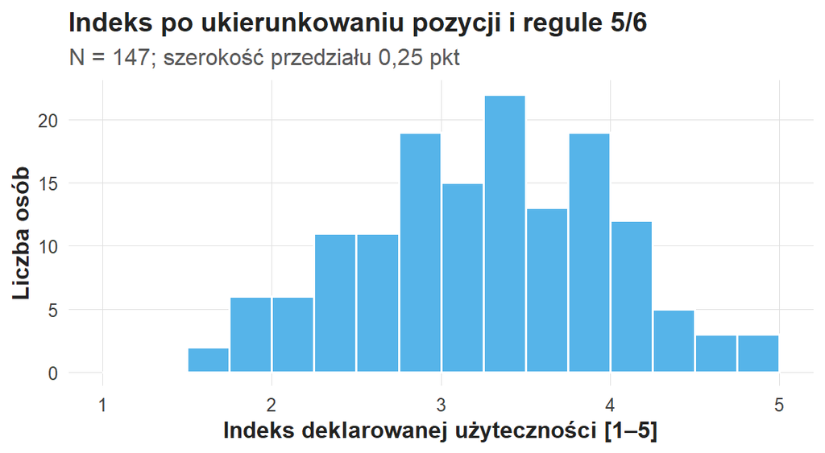

Indeks po ukierunkowaniu pozycji i regule 5/6: histogram 147 indeksów z przedziałami po 0,25 punktu. Oś pozioma: indeks 1–5; oś pionowa: liczba osób. Indeksy leżą od 1,6 do 5,0; najwyższy słupek, 22 osoby, stoi nad przedziałem od 3,25 do 3,5, a słupki obniżają się w obu kierunkach.

```r
rozklad <- pokaz_wykres(wykres_indeksu)
print(rozklad)
```

Wykres „Indeks po ukierunkowaniu pozycji i regule 5/6” ma oś w punktach skali 1–5: średnia wynosi 3,29, SD 0,73, a kwartyle 2,83 i 3,83. Położenie wartości na skali opisuje procent zakresu skali (wykład W02, Język danych, pomiar i opis):

$$\frac{I-1}{5-1}\cdot100\%:\qquad \frac{4-1}{5-1}\cdot100\%=75\% .$$

Indeks 4 leży w 75% zakresu skali 1–5. Przeliczenie na 0–100 zmienia jednostkę prezentacji, a zakres treści pozycji pozostaje ten sam.

## Analiza wrażliwości: pięć czy sześć odpowiedzi

Obowiązującą regułą Z04 jest minimum pięciu pozycji; porównanie z wariantem 6/6 przedstawia konsekwencję ostrzejszej reguły. Tabela „Wariant 5/6 i wariant 6/6 w S02” podaje: reguła 5/6 — N = 147, średnia 3,292, SD 0,727; reguła 6/6 — N = 125, średnia 3,297, SD 0,746.

```r
reguly <- pokaz_tabele(wrazliwosc_minimum, "Wariant 5/6 i wariant 6/6 w S02", 3L)
print(reguly)
```

**Wariant 5/6 i wariant 6/6 w S02**

| Minimum pozycji | N | Braki indeksu | Średnia | SD |
| --- | --- | --- | --- | --- |
| 5 | 147 | 1 | 3,292 | 0,727 |
| 6 | 125 | 23 | 3,297 | 0,746 |

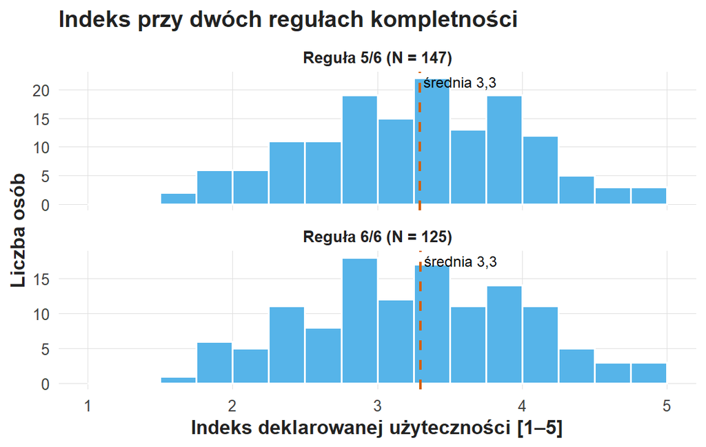

Indeks przy dwóch regułach kompletności: histogramy z przedziałami po 0,25 punktu na wspólnej osi 1–5. Górny panel: reguła 5/6, N = 147; dolny panel: reguła 6/6, N = 125. Kształty obu rozkładów są podobne, a linie przerywane średnich leżą przy 3,3 w obu panelach.

```r
dwie_reguly <- pokaz_wykres(wykres_regul)
print(dwie_reguly)
```

Osoby z sześcioma odpowiedziami mają ten sam indeks w obu wariantach; osoby z pięcioma odpowiedziami w wariancie 6/6 mają brak indeksu. Wariant zmienia kryterium włączenia do podsumowania, a różnica średnich wynika ze zmiany składu osób.

Podobny wynik obu wariantów (3,292 i 3,297) opisuje zbiór S02 i reguły 5/6 oraz 6/6; mechanizm braków pozostaje nieznany. Przypisanie brakowi wartości 3 dodaje deklarację „ani tak, ani nie” i zmniejsza zróżnicowanie. Średnia z dostępnych pozycji jest jawną regułą opartą na zarejestrowanych odpowiedziach.

**Wzorzec zapisu indeksu (APA).**

> Indeks użyteczności katalogu obliczono jako średnią sześciu pozycji (skala 1–5) po przekodowaniu pozycji 3, przy co najmniej pięciu ważnych odpowiedziach. Warunek spełniło 147 ze 148 osób (125 z kompletem sześciu pozycji, 22 z pięcioma); w analizie wrażliwości wymagającej sześciu odpowiedzi indeks ma 125 osób, a losowość braków pozostaje założeniem.

# LEARN 4: pytanie wielokrotnego wyboru

Pytanie o kanały informacji dopuszcza więcej niż jedną odpowiedź. Każdy kanał jest osobną kolumną 0/1: jedynka oznacza wybór, zero — brak wyboru przy znanej odpowiedzi, a `NA` — nieznaną odpowiedź. Jedna osoba wnosi więc od zera do czterech jedynek.

W S02 kanały to strona WWW, e-mail, media społecznościowe i kontakt bezpośredni. Cztery kanały są kategoriami nominalnymi; numer kolumny służy identyfikacji. Liczba wybranych kanałów opisuje szerokość korzystania; użycie liczby kanałów jako miary kompetencji wymaga osobnego uzasadnienia.

Tabela „Wybory osób: 0, 1 oraz brak” obejmuje sześć osób demonstracji. Osoba 3 zaznaczyła 0 przy każdym z czterech kanałów, osoba 4 ma odpowiedź częściową (brak przy e-mailu), a osoba 5 ma braki we wszystkich czterech kolumnach.

```r
kanaly_osob <- dane_kanalow(kanaly_demo)
print(kanaly_osob)
```

**Wybory osób: 0, 1 oraz brak**

| Osoba | WWW | e-mail | media społecznościowe | kontakt bezpośredni |
| --- | --- | --- | --- | --- |
| 1 | 1 | 0 | 1 | 0 |
| 2 | 0 | 1 | 0 | 0 |
| 3 | 0 | 0 | 0 | 0 |
| 4 | 1 | NA | 0 | 0 |
| 5 | NA | NA | NA | NA |
| 6 | 1 | 1 | 0 | 1 |

Reguła kursu używa wspólnego mianownika kompletnych respondentów, czyli osób ze znanymi czterema wartościami: osób 1, 2, 3 i 6. Osoba 3 pozostaje w mianowniku z czterema zerami. Osoby 4 i 5 są pominięte w całej tabeli odsetków. Reguła wspólnego mianownika jest jawnym wyborem analitycznym; odrębne mianowniki kanałów odpowiadają na inne pytanie i wymagają podania każdego mianownika.

## Dwa procenty, dwa pytania

Niech $n_k$ oznacza liczbę kompletnych respondentów wybierających kanał $k$, a $N_c$ — liczbę kompletnych respondentów. Odsetek respondentów wybierających kanał ma postać:

$$P_k=100\%\cdot\frac{n_k}{N_c}.$$

Liczba wskazań kanału podzielona przez sumę wszystkich wskazań daje udział kanału w puli wyborów:

$$U_k=100\%\cdot\frac{n_k}{\sum_h n_h}.$$

Wzór $P_k$ odpowiada na pytanie o osoby, a wzór $U_k$ — o wskazania. Podpis nazywa jednostkę: „procent respondentów” albo „procent wskazań”. W mianowniku $U_k$ osoba wybierająca trzy kanały wnosi trzy jednostki.

Tabele „Mianowniki i kompletność” oraz „Odsetki osób oraz udział w puli wskazań” zestawiają oba wyniki dla demonstracji: 4 kompletnych respondentów, 2 pominięte odpowiedzi i 6 wskazań. WWW wybrały 2 osoby: 50% kompletnych respondentów i 33,3% wskazań.

```r
mianowniki <- opis_kanalow(kanaly_demo_wynik)
print(mianowniki)
```

**Mianowniki i kompletność**

| Miara | Liczba |
| --- | --- |
| Kompletni respondenci | 4 |
| Pominięte niepełne odpowiedzi | 2 |
| Suma wskazań | 6 |

**Odsetki osób oraz udział w puli wskazań**

| Kanał | Wybrali | Osoby [%] | Wskazania [%] |
| --- | --- | --- | --- |
| WWW | 2 | 50 | 33,3 |
| e-mail | 2 | 50 | 33,3 |
| media społecznościowe | 1 | 25 | 16,7 |
| kontakt bezpośredni | 1 | 25 | 16,7 |

Suma procentów respondentów wynosi 150%, bo wybory współwystępują. Suma udziałów wskazań wynosi 100%, gdy istnieje co najmniej jedno wskazanie; udziały wskazań wymagają niezerowej sumy wskazań.

Zdanie „50% osób wybiera WWW” wymaga dopowiedzenia „wśród czterech osób z kompletną odpowiedzią”. Zdanie „WWW ma 33,3% wskazań” dotyczy innej jednostki. Podpis tabeli podaje oba mianowniki, bo odbiorcy często je mylą.

## Kanały w S02

Tabele dla S02 podają: 144 kompletnych respondentów, 4 pominięte niepełne odpowiedzi i 305 wskazań. WWW wskazało 91 osób (63,2%), e-mail 76 (52,8%), media społecznościowe 59 (41,0%), a kontakt bezpośredni 79 (54,9%); suma odsetków respondentów wynosi 211,8%.

```r
wybory <- opis_kanalow(kanaly)
print(wybory)
```

**Mianowniki i kompletność**

| Miara | Liczba |
| --- | --- |
| Kompletni respondenci | 144 |
| Pominięte niepełne odpowiedzi | 4 |
| Suma wskazań | 305 |

**Odsetki osób oraz udział w puli wskazań**

| Kanał | Wybrali | Osoby [%] | Wskazania [%] |
| --- | --- | --- | --- |
| WWW | 91 | 63,2 | 29,8 |
| e-mail | 76 | 52,8 | 24,9 |
| media społecznościowe | 59 | 41,0 | 19,3 |
| kontakt bezpośredni | 79 | 54,9 | 25,9 |

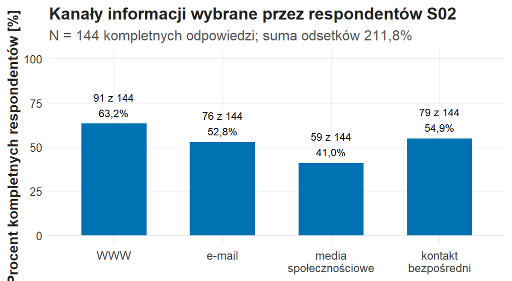

Kanały informacji wybrane przez respondentów S02 (N = 144 kompletnych odpowiedzi). Oś pionowa: procent kompletnych respondentów. Słupki: WWW 91 z 144 (63,2%), e-mail 76 (52,8%), media społecznościowe 59 (41,0%), kontakt bezpośredni 79 (54,9%). Suma odsetków wynosi 211,8%, bo jedna osoba wybiera kilka kanałów.

```r
popularnosc <- pokaz_wykres(wykres_kanalow)
print(popularnosc)
```

Słupki przedstawiają procent kompletnych respondentów; jedna osoba należy do kilku słupków, więc właściwy jest wykres słupkowy z osobnym słupkiem każdego kanału. Popularność kanału opisuje deklarowane korzystanie; skuteczność kanału wymaga kryterium wyniku kontaktu, np. poprawności uzyskanej informacji.

Marginalne liczebności wyznaczają granice liczby osób z dwoma wyborami:

$$\max(0,\ n_A+n_B-N)\le n_{AB}\le \min(n_A,\ n_B).$$

**Próba:** w ankiecie 30 z 50 osób wybiera e-mail, a 25 z 50 — WWW. Suma 55 wskazań przekracza N o 5, więc co najmniej 5 osób wybrało oba kanały; najwięcej osób z oboma wyborami jest 25, czyli tyle, ile wybrało WWW. Wykres „Granice wspólnych wyborów e-maila i WWW” przedstawia oba skrajne układy.

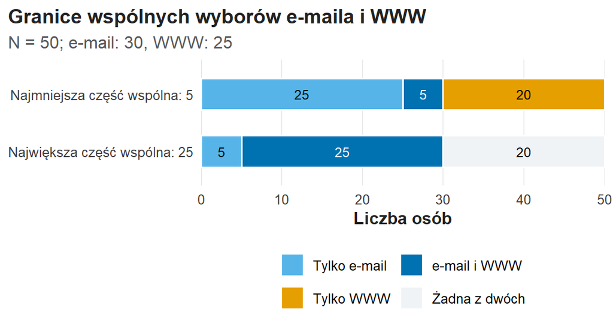

Granice wspólnych wyborów e-maila i WWW przy N = 50, 30 wyborach e-maila i 25 wyborach WWW. Górna belka, układ z najmniejszą częścią wspólną: 25 osób tylko z e-mailem, 5 z oboma kanałami i 20 tylko z WWW. Dolna belka, układ z największą częścią wspólną: 5 osób tylko z e-mailem, 25 z oboma kanałami i 20 osób bez żadnego z dwóch kanałów.

```r
wspolne <- pokaz_wykres(wykres_wspolnych)
print(wspolne)
```

Dokładną liczbę wspólnych wyborów podaje tabela krzyżowa odpowiedzi osób; marginalne liczebności wyznaczają przedział od 5 do 25.

**Wzorzec zapisu odpowiedzi wielokrotnych (APA).**

> Kompletne odpowiedzi o kanałach kontaktu podały 4 z 6 osób; WWW wskazały 2 z nich (50% kompletnych respondentów), a wskazania WWW stanowiły 2 z 6 wszystkich wskazań (33,3%). Osoba bez wskazań (cztery zera) pozostała w mianowniku, a dwie osoby z niepełną odpowiedzią pominięto.

# LEARN 5: deklaracja i obserwacja odpowiadają na różne pytania

## Co znaczy „znalazł dokument”

Hipotetyczne zadanie brzmi: „Znajdź wskazaną publikację i podaj miejsce, z którego można uzyskać pełny tekst”. Sukces definiuje protokół przed obserwacją zachowania: właściwy dokument i prawidłowa droga dostępu.

Protokół obserwacji zadania

| Element protokołu | Przykładowa decyzja |
| --- | --- |
| Początek czasu | Wyświetlenie pełnej instrukcji i sygnał rozpoczęcia |
| Koniec czasu | Zgłoszenie odpowiedzi albo określony limit |
| Sukces | Właściwy dokument i prawidłowa droga dostępu |
| Podpowiedź | Zapis osobny, z momentem udzielenia |
| Rezygnacja | Osobny status wyniku |
| Problem techniczny | Osobna adnotacja i reguła dalszego traktowania |
| Ocena obserwatora | Wspólne kryteria i kontrola zgodności |

Tabela opisuje przyszły protokół. S02 zawiera czas i binarne powodzenie; moment podpowiedzi i rodzaj błędu wymagają osobnych kolumn zapisanych w czasie obserwacji.

Pomiar obserwacyjny ma własne źródła błędu: obecność prowadzącego, trudność zadania, urządzenie i połączenie oraz ocenę obserwatora, który uznaje częściowo poprawną odpowiedź za sukces albo niepowodzenie.

## Dwóch obserwatorów, jedno wykonanie

Dwie oceny jednej próby dotyczą jednego wykonania; N analizy skuteczności pozostaje liczbą prób. Podwójne kodowanie służy ocenie zgodności obserwatorów.

Tabela „Zgodność dwóch obserwatorów w dziesięciu próbach” podaje oceny obserwatorów A i B: obaj uznali 5 prób za sukces i 3 za niepowodzenie, a w 2 próbach oceny się różnią. Każdy obserwator uznał 6 prób za sukces.

```r
zgodnosc <- tabela_zgodnosci()
print(zgodnosc)
```

**Zgodność dwóch obserwatorów w dziesięciu próbach**

| Ocena A | B: sukces | B: niepowodzenie |
| --- | --- | --- |
| A: sukces | 5 | 1 |
| A: niepowodzenie | 1 | 3 |

Procent zgodności $p_o$ zawiera zgodności przypadkowe. Współczynnik kappa Cohena odejmuje zgodność $p_e$ oczekiwaną przy ocenach niezależnych, z udziałami sukcesów $p_A$ i $p_B$ obu obserwatorów:

$$p_o=\frac{8}{10}=0{,}80,\qquad p_e=p_Ap_B+(1-p_A)(1-p_B)=0{,}6\cdot0{,}6+0{,}4\cdot0{,}4=0{,}52,$$

$$\kappa=\frac{p_o-p_e}{1-p_e}=\frac{0{,}80-0{,}52}{0{,}48}=0{,}58 .$$

Zgodność 80% oznacza kappa 0,58: zgodność ponad oczekiwaną wynosi 58% największej możliwej zgodności ponad oczekiwaną. Kryteria sporu, np. uznanie częściowo poprawnej odpowiedzi, wymagają zapisu w protokole.

Pięć zadań jednej osoby to pięć powiązanych pomiarów. Analiza zadań, osób albo zmiany między zadaniami uwzględnia powiązanie pomiarów; ćwiczenie analizuje jedną próbę na osobę.

## Dwa wskaźniki tej samej osoby

Do demonstracji a–f dołączono przykładowe czasy i powodzenie jednego zadania. Dane są dydaktyczne. Tabela „Dwa pomiary tych samych osób a–f” zestawia indeks, czas w minutach i powodzenie 0/1 obok siebie, bo mają różne jednostki.

```r
pomiar <- deklaracja_i_obserwacja()
print(pomiar)
```

**Dwa pomiary tych samych osób a–f**

| Osoba | Indeks [1–5] | Czas [min] | Powodzenie (0/1) |
| --- | --- | --- | --- |
| a | 4,50 | 6 | 1 |
| b | 4,00 | 12 | 0 |
| c | NA | 8 | 1 |
| d | 1,33 | 4 | 0 |
| e | 3,00 | 10 | 1 |
| f | 3,67 | 7 | 1 |

**Wzorzec zapisu deklaracji i wykonania (APA).**

> Osoba a miała indeks deklarowanej użyteczności 4,5 (skala 1–5) i poprawnie wykonała zadanie w 6 min, a osoba b przy indeksie 4 zakończyła zadanie niepowodzeniem po 12 min; deklaracja i wykonanie opisują dwie różne informacje. Osoba c ma wynik obserwacyjny (sukces po 8 min) i brak indeksu.

Ocena kompetencji wymaga zadań o zdefiniowanej treści i trudności oraz kryteriów poprawności; indeks oceny usługi uzupełnia pomiar wykonania. Opis osoby jako kompetentnej wymaga wielu zadań z wybranego obszaru.

# CHALLENGE — samodzielny audyt pomiaru

Osiem hipotetycznych osób ocenia interfejs cyfrowego archiwum. Pozycje brzmią: p1 — łatwo znaleźć pole wyszukiwania; p2 — etykiety filtrów są zrozumiałe; p3 — odczytanie rekordu wymaga zgadywania; p4 — łatwo ustalić dostęp do obiektu; p5 — komunikaty pomagają zmienić zapytanie; p6 — interfejs wspiera wykonanie zadania. Odpowiedzi: 1 zdecydowanie nie, 2 raczej nie, 3 ani tak, ani nie, 4 raczej tak, 5 zdecydowanie tak; braki zapisano jako NA. Indeks jest średnią co najmniej pięciu ukierunkowanych pozycji, a odwrócenia wymaga wyłącznie p3.

Każde z pięciu zadań ma ten sam układ:

1. **Zadanie** — jedno zdanie z przedmiotem opisu.
2. **Blok R** — uruchom go; wynik zawiera wszystkie liczby potrzebne do odpowiedzi.
3. **Wskazówki** — gdzie w wyniku szukać informacji, jak ją nazwać i wzór zdania do uzupełnienia.
4. **W akapicie wymagane** — elementy, które sprawdza prowadzący.
5. **Twój akapit** — pole odpowiedzi w ramce: znacznik w nawiasie kwadratowym zastępujesz własnym tekstem, a linie komentarza nad nim i pod nim pozostawiasz bez zmian.

Akapit liczy 3–5 zdań zwykłego tekstu, bez kodu R. Liczby przepisujesz z wyniku bloku, z jednostką i mianownikiem.

## CHALLENGE 1: Rozkład pojedynczej pozycji

**Zadanie:** opisz rozkład odpowiedzi na pozycję p2 z mianownikiem, brakiem i odsetkiem zgody.

```r
pozycja_archiwum <- opis_pozycji_archiwum()
print(pozycja_archiwum)
```

**Pierwotne pozycje cyfrowego archiwum**

| Osoba | p1 | p2 | p3 | p4 | p5 | p6 |
| --- | --- | --- | --- | --- | --- | --- |
| a1 | 4 | 4 | 2 | 5 | 4 | 4 |
| a2 | 5 | 4 | 1 | 5 | 4 | 5 |
| a3 | 3 | 3 | 3 | 3 | 3 | 3 |
| a4 | 2 | 2 | 4 | 2 | 1 | 2 |
| a5 | 4 | NA | 2 | 4 | NA | 5 |
| a6 | 1 | 2 | 5 | 1 | 2 | 1 |
| a7 | 5 | 5 | 1 | NA | 5 | 5 |
| a8 | 3 | 3 | 3 | 3 | 3 | 3 |

**Rozkład p2: etykiety filtrów są zrozumiałe**

| Odpowiedź | Liczba | N | Braki | Procent [%] |
| --- | --- | --- | --- | --- |
| 1 | 0 | 7 | 1 | 0,0 |
| 2 | 2 | 7 | 1 | 28,6 |
| 3 | 2 | 7 | 1 | 28,6 |
| 4 | 2 | 7 | 1 | 28,6 |
| 5 | 1 | 7 | 1 | 14,3 |

**Zgoda z p2**

| Odpowiedzi | Liczba | N | Procent [%] |
| --- | --- | --- | --- |
| 4 lub 5 (zgoda) | 3 | 7 | 42,9 |

Blok wyświetla tabelę „Pierwotne pozycje cyfrowego archiwum” (osiem osób, sześć pozycji), tabelę „Rozkład p2: etykiety filtrów są zrozumiałe” (liczba i procent każdej odpowiedzi z N i brakami) oraz tabelę „Zgoda z p2” (odpowiedzi 4 lub 5).

*Wskazówki:*

- Pozycja p2 ma skalę porządkową: kody 1–5 mają kolejność, a odległości między kategoriami pozostają nieznane.
- Mianownik odsetków to liczba ważnych odpowiedzi N; osoba z brakiem odpowiedzi wypada z mianownika.
- Zgoda to suma odpowiedzi 4 i 5; tabela „Zgoda z p2” podaje liczbę, N i procent.
- Wzorzec APA: „Na pozycję p2 („[treść]”, skala 1–5) odpowiedziało [N] z 8 osób ([..] brak). Najczęściej wybierano odpowiedzi [..], a zgodę (odpowiedzi 4 lub 5) wyraziło [..] z [N] osób ([..]%)”.

*W akapicie wymagane:* (i) treść p2 i porządkowa skala odpowiedzi; (ii) N ważnych odpowiedzi i liczba braków; (iii) rozkład odpowiedzi; (iv) odsetek zgody z licznikiem i mianownikiem; (v) wpływ braku odpowiedzi na mianownik.

**Twój akapit S01.** Znacznik w nawiasie kwadratowym zastąp własnym tekstem.

## CHALLENGE 2: Kierunek i mianownik indeksu

**Zadanie:** wyjaśnij odwrócenie p3, odtwórz indeks osoby a1 i uzasadnij brak indeksu osoby a5.

```r
indeks_archiwum <- konstrukcja_indeksu_archiwum()
print(indeks_archiwum)
```

**Rekord a1 przed odwróceniem p3 i po nim**

| Zapis | p1 | p2 | p3 | p4 | p5 | p6 |
| --- | --- | --- | --- | --- | --- | --- |
| Pierwotne odpowiedzi a1 | 4 | 4 | 2 | 5 | 4 | 4 |
| Po odwróceniu p3 (6 − x) | 4 | 4 | 4 | 5 | 4 | 4 |

**Audyt poprawnego indeksu**

| Osoba | Ważne pozycje m | Suma ważnych | Indeks I |
| --- | --- | --- | --- |
| a1 | 6 | 25 | 4,17 |
| a2 | 6 | 28 | 4,67 |
| a3 | 6 | 18 | 3,00 |
| a4 | 6 | 11 | 1,83 |
| a5 | 4 | 17 | NA |
| a6 | 6 | 8 | 1,33 |
| a7 | 5 | 25 | 5,00 |
| a8 | 6 | 18 | 3,00 |

**Błędny oraz poprawny kierunek pozycji**

| Osoba | Bez odwrócenia | Po odwróceniu |
| --- | --- | --- |
| a1 | 3,83 | 4,17 |
| a2 | 4,00 | 4,67 |
| a3 | 3,00 | 3,00 |
| a4 | 2,17 | 1,83 |
| a5 | NA | NA |
| a6 | 2,00 | 1,33 |
| a7 | 4,20 | 5,00 |
| a8 | 3,00 | 3,00 |

Blok wyświetla tabelę „Rekord a1 przed odwróceniem p3 i po nim”, tabelę „Audyt poprawnego indeksu” (liczba ważnych pozycji, suma ważnych odpowiedzi i indeks każdej osoby) oraz tabelę „Błędny oraz poprawny kierunek pozycji” (indeks bez odwrócenia p3 i po odwróceniu).

*Wskazówki:*

- Pozycja p3 mówi o zgadywaniu, więc wysoka odpowiedź oznacza trudność; odwrócenie 6 − x nadaje jej kierunek pozostałych pozycji.
- Indeks a1 to suma sześciu ukierunkowanych odpowiedzi podzielona przez liczbę ważnych pozycji: odczytaj licznik i mianownik z tabeli audytu.
- Osoba a5 ma cztery ważne pozycje, a reguła wymaga co najmniej pięciu.
- Nazwa konstruktu wynika z treści pozycji: dotyczą one deklarowanej użyteczności interfejsu archiwum.
- Wzorzec APA: „Pozycję p3 przekodowano według wzoru 6 − *x*. Indeks osoby a1 wynosi [suma]/[m] = [..] (bez odwrócenia: [..]). Osoba a5 ma [..] ważne pozycje, więc indeks pozostaje brakiem”.

*W akapicie wymagane:* (i) kierunek p3 powiązany z jej treścią; (ii) licznik i mianownik indeksu a1 z regułą 6 − x; (iii) porównanie z wersją bez odwrócenia; (iv) uzasadnienie braku indeksu a5; (v) pełna nazwa konstruktu zgodna z treścią pozycji.

**Twój akapit S02.** Znacznik w nawiasie kwadratowym zastąp własnym tekstem.

## CHALLENGE 3: Reguła 5/6 wobec 6/6

Zaostrzenie reguły kompletności zmienia zestaw osób z indeksem i może wykluczyć osoby o specyficznych trudnościach; regułę ustala się przed obliczeniami.

**Zadanie:** porównaj regułę minimum pięciu i minimum sześciu pozycji i opisz ich skutek dla liczby indeksów.

```r
reguly_archiwum <- kompletnosc_archiwum()
print(reguly_archiwum)
```

**Wynik każdej osoby w dwóch wariantach**

| Osoba | Minimum 5 | Minimum 6 |
| --- | --- | --- |
| a1 | 4,17 | 4,17 |
| a2 | 4,67 | 4,67 |
| a3 | 3,00 | 3,00 |
| a4 | 1,83 | 1,83 |
| a5 | NA | NA |
| a6 | 1,33 | 1,33 |
| a7 | 5,00 | NA |
| a8 | 3,00 | 3,00 |

**Liczby ważnych indeksów**

| Minimum pozycji | Ważne indeksy |
| --- | --- |
| 5 | 7 |
| 6 | 6 |

Blok wyświetla tabelę „Wynik każdej osoby w dwóch wariantach” (indeks przy minimum 5 i przy minimum 6) oraz tabelę „Liczby ważnych indeksów”.

*Wskazówki:*

- Porównaj kolumny obu wariantów wiersz po wierszu: status zmienia się u osoby z pięcioma ważnymi pozycjami.
- Indeksy osób z kompletem sześciu pozycji są w obu wariantach takie same; zmienia się zbiór osób opisany wynikiem.
- Analiza podstawowa stosuje regułę z opisu badania (minimum 5), a wariant 6/6 może towarzyszyć jej jako jawna analiza wrażliwości.
- Wzorzec APA: „Przy regule co najmniej pięciu ważnych pozycji indeks obliczono dla [..] z 8 osób; wymaganie sześciu pozycji zmniejsza tę liczbę do [..], ponieważ osoba [..] ma [..] ważnych pozycji”.

*W akapicie wymagane:* (i) N indeksów w obu wariantach; (ii) osoba, której status się zmienia, z jej wynikiem; (iii) uzasadnienie analizy podstawowej; (iv) sposób przedstawienia drugiego wariantu jako analizy wrażliwości.

**Twój akapit S03.** Znacznik w nawiasie kwadratowym zastąp własnym tekstem.

## CHALLENGE 4: Kanały pomocy

Archiwum pyta o korzystanie z WWW, e-maila, mediów społecznościowych i kontaktu bezpośredniego i dopuszcza wiele wskazań. Obowiązuje wspólny mianownik kompletnych respondentów, jak w LEARN 4.

**Zadanie:** opisz wybór WWW dwoma procentami — wśród kompletnych respondentów i wśród wszystkich wskazań.

```r
kanaly_archiwum <- kanaly_pomocy_archiwum()
print(kanaly_archiwum)
```

**Surowe wybory kanałów**

| Osoba | WWW | e-mail | media społecznościowe | kontakt bezpośredni |
| --- | --- | --- | --- | --- |
| a1 | 1 | 1 | 0 | 0 |
| a2 | 1 | 0 | 1 | 0 |
| a3 | 0 | 0 | 0 | 0 |
| a4 | 0 | 1 | 0 | 1 |
| a5 | 1 | NA | 0 | 0 |
| a6 | NA | NA | NA | NA |
| a7 | 0 | 0 | 1 | 0 |
| a8 | 1 | 1 | 0 | 0 |

**Mianowniki i kompletność**

| Miara | Liczba |
| --- | --- |
| Kompletni respondenci | 6 |
| Pominięte niepełne odpowiedzi | 2 |
| Suma wskazań | 9 |

**Odsetki osób oraz udział w puli wskazań**

| Kanał | Wybrali | Osoby [%] | Wskazania [%] |
| --- | --- | --- | --- |
| WWW | 3 | 50,0 | 33,3 |
| e-mail | 3 | 50,0 | 33,3 |
| media społecznościowe | 2 | 33,3 | 22,2 |
| kontakt bezpośredni | 1 | 16,7 | 11,1 |

Blok wyświetla tabelę „Surowe wybory kanałów” z zerami, jedynkami i brakami, tabelę „Mianowniki i kompletność” (kompletni respondenci, pominięte niepełne odpowiedzi, suma wskazań) oraz tabelę „Odsetki osób oraz udział w puli wskazań”.

*Wskazówki:*

- Kompletny respondent ma cztery wartości 0 albo 1; osoba z czterema zerami odpowiedziała i pozostaje w mianowniku.
- Osoby z brakiem w którymkolwiek kanale są pominięte zgodnie z regułą wspólnego mianownika.
- Procent osób dzieli liczbę osób wybierających kanał przez liczbę kompletnych respondentów; udział we wskazaniach dzieli liczbę wyborów kanału przez sumę wszystkich wskazań.
- Procenty osób mogą sumować się powyżej 100%, bo jedna osoba wybiera kilka kanałów.
- Wzorzec APA: „Kompletne odpowiedzi o kanałach podało [..] z 8 osób; WWW wskazało [..] z nich ([..]% kompletnych respondentów), a wskazania WWW stanowiły [..] z [..] wszystkich wskazań ([..]%)”.

*W akapicie wymagane:* (i) N kompletnych respondentów; (ii) liczba i procent osób wybierających WWW; (iii) udział WWW we wszystkich wskazaniach; (iv) wyjaśnienie różnicy dwóch procentów; (v) traktowanie kompletu zer i braków.

**Twój akapit S04.** Znacznik w nawiasie kwadratowym zastąp własnym tekstem.

## CHALLENGE 5: Nazwa konstruktu i zakres wniosku

Kierownik chce opisać wysoki indeks jako dowód kompetencji cyfrowej. Pozycje archiwum dotyczą deklarowanej użyteczności interfejsu, a wykonanie pojedynczego zadania jest osobnym pomiarem; związek statystyczny indeksu i wykonania liczy ćwiczenie C08 (Samoocena a wykonanie).

**Zadanie:** popraw tezę kierownika na podstawie wyników co najmniej dwóch osób i zaproponuj pomiar kompetencji.

```r
pomiar_archiwum_tabela <- pomiar_archiwum()
print(pomiar_archiwum_tabela)
```

**Indeks deklaracji i wynik zadania**

| Osoba | Indeks [1–5] | Czas [min] | Sukces (0/1) |
| --- | --- | --- | --- |
| a1 | 4,17 | 6 | 1 |
| a2 | 4,67 | 12 | 0 |
| a3 | 3,00 | 8 | 1 |
| a4 | 1,83 | 4 | 0 |
| a5 | NA | 9 | 1 |
| a6 | 1,33 | 3 | 0 |
| a7 | 5,00 | 15 | 1 |
| a8 | 3,00 | 7 | 1 |

Blok wyświetla tabelę „Indeks deklaracji i wynik zadania” z ośmioma osobami: indeks 1–5, czas w minutach i sukces 0/1.

*Wskazówki:*

- Znajdź osoby, u których indeks i wynik zadania się rozchodzą, np. wysoki indeks i niepowodzenie albo niski indeks i sukces.
- Pojedyncza pozycja opisuje jedną deklarację, indeks — średnią deklaracji, a zadanie — obserwację wykonania.
- Pomiar kompetencji wymaga kilku zadań o różnej trudności i kryterium poprawności każdego zadania.
- Wzorzec APA: „Osoba [..] miała indeks deklarowanej użyteczności [..] (skala 1–5) i [wynik] po [..] min, a osoba [..] przy indeksie [..] — [wynik] po [..] min. Indeks opisuje deklarowaną użyteczność interfejsu; ocena kompetencji wymaga [..]”.

*W akapicie wymagane:* (i) wyniki co najmniej dwóch osób z indeksem, czasem i sukcesem; (ii) rozróżnienie pozycji, indeksu i obserwacji wykonania; (iii) nazwa indeksu zgodna z treścią pozycji; (iv) proponowane zadania i kryterium poprawności do badania kompetencji.

**Twój akapit S05.** Znacznik w nawiasie kwadratowym zastąp własnym tekstem.

# Zapis i oddanie

Sprawdź pięć własnych odpowiedzi: nazwa indeksu odpowiada treści pytań, a każdy procent — wskazanemu mianownikowi. Każde zdanie o „kompetencji”, „skuteczności” lub „ocenie” ma właściwy wskaźnik. Zapisz plik `zadanie.Rmd` w edytorze (Ctrl+S); funkcja oddania tworzy PDF z zapisanego pliku.

W konsoli wykonaj jedno polecenie. Funkcja oddania tworzy aktualny PDF, sprawdza kompletność, otwiera PDF do obejrzenia i po potwierdzeniu literą `t` wysyła go do folderu zadania prowadzącego na serwerze UJ (nc.uj.edu.pl). Nazwa pliku zawiera Twoje ID oraz nazwisko i imię.

```r
oddaj_zadanie("Z04")
```

Oddanie potwierdza komunikat z nazwą wysłanego pliku, folderem i czasem; plik `oddania.csv` w folderze `moje-badania` zapisuje także sumę SHA-256 wysłanego PDF. Po komunikacie błędu popraw wskazany problem, zapisz plik i ponownie wywołaj `oddaj_zadanie("Z04")`; nowa wersja trafia do folderu obok poprzedniej. Ocenę prowadzący przekazuje osobno.

Po potwierdzonym oddaniu możesz zamknąć projekt: Posit Cloud zachowuje folder `moje-badania` do kolejnych zajęć. Na komputerze współdzielonym wyloguj się z Posit Cloud w przeglądarce. Przy braku sieci PDF pozostaje w folderze zadania; wyślij go tym samym poleceniem po odzyskaniu połączenia, a gdy problem trwa, poproś prowadzącego o ustalenie sposobu dostarczenia pracy.

## Co jest oceniane

| Kryterium | Dowód w Twojej pracy | Odpowiedzi | Punkty |
| --- | --- | --- | --- |
| Z04.1 Odczyt gotowego słownika i znaczenia pozycji | Porządkowa skala p2, treść oceny, zakres 1–5, N, braki i odsetek zgody 4–5; przeciwny kierunek p3 powiązany z jej treścią | S01, S02 | 3 |
| Z04.2 Rekodacja i reguła indeksu przy brakach | Reguła $6-x$, licznik i mianownik indeksu a1, brak indeksu a5; N i status a7 przy 5/6 oraz 6/6, reguła 5/6 jako podstawowa | S02, S03 | 3 |
| Z04.3 Mianowniki odpowiedzi wielokrotnych | Liczba wskazań WWW, procent respondentów i procent wskazań z mianownikami; komplet zer odróżniony od braku | S04 | 2 |
| Z04.4 Ocena usługi, indeks i obserwowane wykonanie | Teza o kompetencjach poprawiona na dwóch rekordach indeks–czas–sukces; pozycja, indeks i obserwacja rozdzielone; treść zadań i kryterium poprawności | S01, S05 | 2 |

Ocena dotyczy zgodności zdania z danymi. Poziomy wykonania opisuje rubryka Z04: na stronie kursu w dokumencie `rubryki/Z04.html`, a w konsoli R po poleceniu `rubryka("Z04")`.

# Rozwinięcia do powtórki — poza rdzeniem spotkania

Rozwinięcia rozwijają temat pomiaru: profil odpowiedzi, rzetelność i trafność, zakres konstruktu, recenzję gotowych zdań oraz porównywalność indeksu. Rozwinięcia służą powtórce i pozostają poza oceną.

## Ten sam indeks, różne odpowiedzi

Dwie hipotetyczne osoby mają po sześć ukierunkowanych odpowiedzi. Pierwsza zaznacza wszędzie 3, druga odpowiada 1, 5, 3, 5, 1, 3. Obie mają indeks 3 i dwa różne profile.

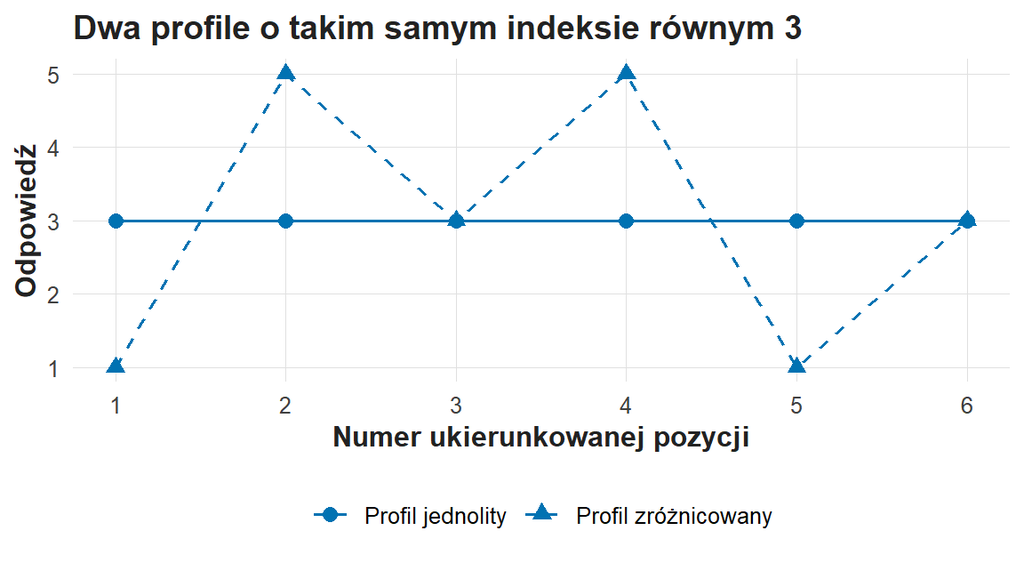

Dwa profile o takim samym indeksie równym 3. Oś pozioma: numer ukierunkowanej pozycji 1–6; oś pionowa: odpowiedź 1–5. Linia ciągła z kołami: profil jednolity, sześć odpowiedzi 3. Linia przerywana z trójkątami: profil zróżnicowany, odpowiedzi 1, 5, 3, 5, 1, 3.

```r
profile_osob <- pokaz_wykres(wykres_profili)
print(profile_osob)
```

Indeks skraca informację i ułatwia analizę kosztem szczegółu. Raport uzasadnia, dlaczego skrót odpowiada pytaniu; przy celu „poprawa etykiet filtrów” właściwym wskaźnikiem jest pozycja 2 i obserwacja zadania.

## Jakość pomiaru

### Rzetelność i trafność

Rzetelność dotyczy spójności lub precyzji pomiaru w określonym modelu. Trafność dotyczy uzasadnienia interpretacji wyniku do konkretnego celu. Narzędzie może konsekwentnie mierzyć cechę inną od opisywanej.

Sześć niemal identycznych pytań o kolorystykę katalogu daje silnie współwystępujące odpowiedzi. Wysoka zgodność odpowiedzi o kolorystyce opisuje spójność jednej treści; ocena wiarygodności źródła, znajdowanie dokumentu i formułowanie zapytań wymagają innych pozycji.

Alfa Cronbacha łączy liczbę pozycji $K$, wariancje pozycji $s_k^2$ i wariancję sumy pozycji $s_X^2$:

$$\alpha=\frac{K}{K-1}\left(1-\frac{\sum_k s_k^2}{s_X^2}\right),\qquad
\alpha_{\text{st}}=\frac{K\bar r}{1+(K-1)\bar r},$$

gdzie $\bar r$ jest średnią korelacją par pozycji. Wykres „Korelacje sześciu pozycji S02” podaje korelacje 15 par pozycji dla 125 osób z kompletem odpowiedzi.

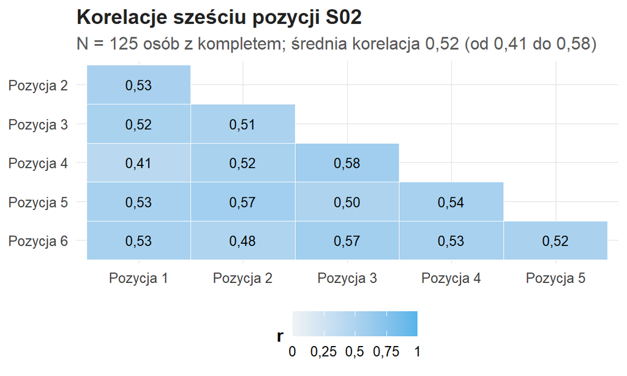

Korelacje sześciu pozycji S02 (N = 125 osób z kompletem). Każda komórka podaje współczynnik korelacji Pearsona pary pozycji; wartości leżą od 0,41 (pozycje 1 i 4) do 0,58 (pozycje 3 i 4), a średnia wynosi 0,52.

```r
korelacje_pozycji <- pokaz_wykres(wykres_korelacji)
print(korelacje_pozycji)
```

Tabela „Alfa Cronbacha sześciu pozycji S02” podaje składniki wzoru: suma wariancji pozycji 5,544, wariancja sumy 20,009, więc $\alpha=\tfrac{6}{5}(1-5{,}544/20{,}009)=0{,}868$; średnia korelacja 0,522 daje $\alpha_{\text{st}}=6\cdot0{,}522/(1+5\cdot0{,}522)=0{,}868$.

```r
alfa_s02 <- alfa_cronbacha()
print(alfa_s02)
```

**Alfa Cronbacha sześciu pozycji S02**

| Miara | Wartość |
| --- | --- |
| Osoby z kompletem pozycji | 125,000 |
| Liczba pozycji K | 6,000 |
| Suma wariancji pozycji | 5,544 |
| Wariancja sumy pozycji | 20,009 |
| Alfa Cronbacha | 0,868 |
| Średnia korelacja pozycji | 0,522 |
| Alfa standaryzowana | 0,868 |

Alfa rośnie ze średnią korelacją pozycji i z liczbą pozycji; jednowymiarowość i trafność wymagają osobnych dowodów. Dane S02 pochodzą z generatora, więc wartość 0,868 opisuje konstrukcję zbioru dydaktycznego. Badanie jakości narzędzia obejmuje ocenę treści przez ekspertów, sprawdzenie rozumienia pytań, strukturę odpowiedzi, związki z zewnętrznymi kryteriami i działanie w różnych grupach.

### Błąd losowy, błąd systematyczny i kontekst odpowiedzi

Osoba zaznacza raz 3, a innym razem 4 z powodu chwilowego wahania. Inna osoba systematycznie zawyża ocenę, by wypaść dobrze. Jeszcze inna interpretuje „szybko” według własnego punktu odniesienia. Trzy mechanizmy — wahanie, autoprezentacja i punkt odniesienia — mają różne skutki: większe N zmniejsza wpływ wahania na średnią, a autoprezentacja i punkt odniesienia pozostają.

W zapisie $X=T+E$ obserwowany wynik $X$ jest sumą wyniku prawdziwego $T$ w danym modelu i błędu $E$. Zapis przypomina, że obserwowany wynik zawiera błąd pomiaru; części $T$ i $E$ pozostają nieobserwowane.

Sposób zadania pytania wpływa na interpretację. Zdanie „Zawsze bez trudu znajduję wiarygodne źródła” łączy mocny kwantyfikator z szerokim zadaniem. Zdanie „W ostatnim zadaniu potrafiłem wskazać autora i datę publikacji” jest węższe i osadzone w sytuacji; drugie zdanie precyzyjniej określa sytuację odniesienia.

### Treść pozycji a ramy kompetencji

[DigComp 2.2](https://publications.jrc.ec.europa.eu/repository/handle/JRC128415) oraz [ACRL Framework](https://www.ala.org/acrl/standards/ilframework) opisują obszary kompetencji. Ramy pomagają nazwać obszary spoza pomiaru S02.

Badanie oceny źródła wymaga wskaźników oceny źródła. Badanie współpracy cyfrowej wymaga wskaźników współpracy, a czas znalezienia sygnatury opisuje inny obszar. Badanie transformacji usługi rozdziela wdrożenie narzędzia, korzystanie, doświadczenie i rezultat. Każdy obszar wymaga własnych wskaźników.

Prosty indeks uczy rachunku i języka, a krytyczny opis wyznacza zakres znaczenia indeksu.

## Dodatkowe przykłady: od liczby do sensu

### Próba A: „wysokie kompetencje, bo średnia 4,2”

Autor podaje indeks 4,2 i pisze, że użytkownicy są bardzo kompetentni cyfrowo. Opis wymaga informacji, czy 4,2 jest wynikiem jednej osoby, czy średnią w próbie, a także treści pozycji, N i reguły braków.

Poprawiony opis dla S02 mówi o deklarowanej użyteczności katalogu i podaje, że indeks jest dydaktyczny: odpowiedzi leżą przeciętnie bliżej korzystnego końca skali przy przyjętej regule. Wniosek dotyczy deklarowanej użyteczności katalogu.

### Próba B: „wszyscy zaznaczyli 3, więc nie mają zdania”

W kodowaniu S02 odpowiedź 3 oznacza „ani tak, ani nie”. Odpowiedź 3 może wyrażać zrównoważoną ocenę albo niepewność; motyw wyboru wymaga osobnego pytania.

Poprawny opis podaje częstość kategorii, a mechanizm pozostawia jako pytanie otwarte. Rozróżnienie oceny neutralnej, „nie dotyczy” i „nie umiem ocenić” projektuje się w ankiecie przed zebraniem danych.

### Próba C: „kanały muszą sumować się do stu”

Autor dzieli procenty respondentów przez ich sumę, aby wykres sumował się do 100%. Wynikiem są procenty wskazań podpisane jako procenty użytkowników: zmienia się pytanie, a opis pozostaje stary.

Poprawa polega na zachowaniu oryginalnego mianownika albo jawnym nazwaniu nowej wielkości. W demonstracji WWW wybiera 50% kompletnych respondentów i ma 33,3% wszystkich wskazań; oba wyniki są poprawne jako dwie różne wielkości.

### Próba D: wysoka ocena i niepowodzenie

Osoba wysoko ocenia katalog i nie znajduje właściwego dokumentu. Rekord zostaje w danych: ocena doświadczenia i rezultat działania mogą się różnić. Osoba mogła przeoczyć własny błąd, zadanie mogło być nietypowe, a kryterium sukcesu — inne od kryterium osoby.

Trzy wyjaśnienia są hipotezami. Rekord spełniający reguły jakości danych pozostaje, a rozbieżność staje się pytaniem badawczym. Ćwiczenie C08 liczy związek obu wskaźników; wskaźniki pozostają dwoma pomiarami.

### Próba E: „indeks wzrósł, więc interfejs pomógł”

Hipotetyczny projekt mierzy ocenę przed zmianą interfejsu i po zmianie. Przypisanie przyczyny wzrostu średniej wymaga projektu: zmienić się mogli użytkownicy, zadania, sposób zaproszenia do ankiety i warunki.

Pomiar tych samych osób wymaga zachowania par, a pomiar innych osób daje dwa zbiory o możliwie różnym składzie. Informacje o randomizacji, czasie i kontroli wyjaśnień pochodzą z opisu projektu.

## Pracownia recenzenta: czy liczba zachowuje znaczenie

### Średnia osób czy średnia odpowiedzi

W dodatkowej demonstracji jedna osoba ma sześć ważnych odpowiedzi o średniej 2, a druga — pięć odpowiedzi o średniej 5. Obie spełniają regułę minimum. Pytanie dotyczy przeciętnego indeksu osoby.

Dwie osoby o różnej liczbie odpowiedzi

| Osoba | Liczba pozycji | Suma odpowiedzi | Indeks |
| --- | --- | --- | --- |
| Pierwsza | 6 | 12 | 2 |
| Druga | 5 | 25 | 5 |

$$\bar I=\frac{1}{N}\sum_i I_i=\frac{2+5}{2}=3{,}5,\qquad
\frac{\sum_i\sum_{k\in O_i}x^*_{ik}}{\sum_i m_i}=\frac{12+25}{6+5}=\frac{37}{11}=3{,}36 .$$

Średnia indeksów nadaje każdej osobie tę samą wagę. Średnia wszystkich odpowiedzi nadaje pierwszej osobie większą wagę, bo odpowiedziała na więcej pytań. Dwa rachunki opisują dwie wielkości: średnią osób (N = 2) i średnią odpowiedzi (11 odpowiedzi dwóch osób).

Estymanda „przeciętny wynik osoby” określa jednostkę ważenia: indeks powstaje dla osoby, a opis dotyczy rozkładu indeksów osób. Raport podaje, co uśredniano i w jakiej kolejności.

### Odpowiedź 4 u początkującego i u eksperta

Początkujący użytkownik ocenia „szybkie wyszukiwanie” względem pierwszej wizyty, a ekspert — względem narzędzia używanego zawodowo. Identyczny kod może mieć różne punkty odniesienia; porównanie wymaga sprawdzenia porównywalności.

Przed porównaniem średnich raport sprawdza, czy instrukcja, kontekst zadania i treść pozycji są porównywalne. Modele niezmienniczości pomiaru należą do metod zaawansowanych; różnica indeksów łączy różnicę oceny z różnicą używania skali.

Standaryzacja w każdej grupie osobno ustawia średnie grup na zero, więc usuwa różnicę położenia, o którą pyta analiza.

### Efekt podłogowy i sufitowy

Przy indeksach bliskich 5 skala ma mało miejsca na wzrost (efekt sufitowy); poprawa doświadczenia może pozostać poza zasięgiem narzędzia. Analogiczne zjawisko przy dolnej granicy skali nosi nazwę efektu podłogowego.

Rozkład pozycji i indeksu ujawnia oba efekty. Małe SD może wynikać z podobnych ocen albo z ograniczenia zakresu i pytań łatwych do potwierdzenia; rozstrzygnięcie wymaga rozkładu pozycji.

Rozwiązaniem może być precyzyjniejsze pytanie, inny zakres trudności zadań lub wskaźnik obserwacyjny. Każda zmiana narzędzia wymaga opisu, bo utrudnia porównanie z pomiarem sprzed zmiany.

### Miniaturowa recenzja narzędzia

Opis do recenzji brzmi: „Badani oceniali sześć stwierdzeń od 1 do 5. Zsumowaliśmy wszystkie odpowiedzi, brakom przypisaliśmy 3, a wysoki wynik nazwaliśmy kompetencją cyfrową. Następnie porównaliśmy go z liczbą kliknięć i ustaliliśmy, kto jest dobrym użytkownikiem”.

Recenzja wskazuje cztery problemy. Pierwszy: opis pomija treść i kierunek pozycji, więc znaczenie sumy pozostaje nieznane. Drugi: przypisanie brakom kategorii środkowej dodaje odpowiedzi, których osoby nie udzieliły. Trzeci: szeroka nazwa konstruktu wymaga uzasadnienia treścią pozycji. Czwarty: liczba kliknięć opisuje przebieg interakcji, a jakość działania wymaga kryterium poprawności.

Lepsza wersja jest krótka: definiuje treść indeksu, opisuje rekodację i minimum, podaje N osób oraz porównuje deklarację z określonym wynikiem zadania, bez etykietowania uczestników. Cel recenzji: sprawdzić, czy pomiar odpowiada problemowi.

## Co zabieramy do C05

Wykład W03 (Losowość, estymacja i dwa tory wnioskowania) i ćwiczenie C05 (Niepewność estymaty) wprowadzają niepewność średniej i porównanie z umownym punktem odniesienia. Treść pytań ocenia badacz; precyzja statystyczna i trafność pomiaru to dwie osobne cechy wyniku.

Trzy zdania służą własnej kontroli: „wiem, co oznacza wysoka wartość”, „wiem, które odpowiedzi tworzą wynik” i „wiem, jaki zakres konstruktu obejmuje wynik”. Z tymi trzema zdaniami test statystyczny staje się rozmową o problemie badawczym.